# Anàlisi de la Covariància

Antonio Miñarro (aminarro@ub.edu)

12 gener, 2026

# 1 ANCOVA

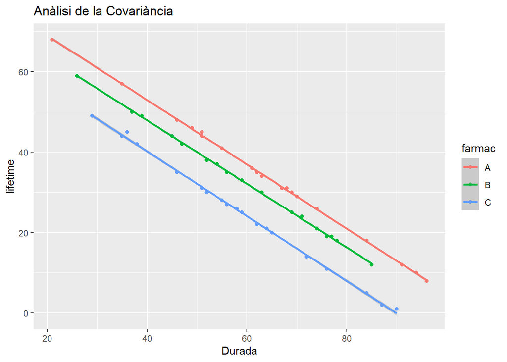

## 1.1 Exemple: Eficàcia d’uns fàrmacs contra una variant de càncer

Volem estudiar tres possibles tractaments contra una variant especialment agressiva de càncer.

La variable resposta són els mesos de vida (**lifetime**) després d’iniciar el tractament.

Un grup de 60 pacients diagnosticats de la variant són aleatoritzats als tres tractaments i l’experiment continua fins tenir informació del temps que han sobreviscut.

Ens decidim a fer un anova d’un factor considerant el tractament com un factor fix y els mesos de vida com a variable resposta.

Les dades es troben al fitxer **cancer.csv** que consta de les següents columnes:

1. **lifetime**: mesos de vida després d’iniciar el tractament
2. **farmac**: tractament rebut (A, B o C)
3. **Durada**: mesos diagnosticat abans d’iniciar el tractament
4. **Sexe**: gènere del pacient
5. **Edat**: edat del pacient a l’inici del tractament

```r
cancer<-read.table('../dades/cancer.csv',header=T,sep=';',dec=',',stringsAsFactors = T)
head(cancer)
```

| lifetime | farmac | Durada | Sexe | Edat |
| --- | --- | --- | --- | --- |
| 46 | A | 49 | home | 59 |
| 41 | A | 55 | dona | 60 |
| 12 | A | 91 | home | 60 |
| 36 | A | 61 | dona | 43 |
| 34 | A | 63 | home | 52 |
| 10 | A | 94 | home | 54 |

## 1.2 Anàlisi descriptiu de les dades

```r
summary(cancer)
```

```
##     lifetime     farmac     Durada        Sexe         Edat
##  Min.   : 1.00   A:20   Min.   :21.00   dona:24   Min.   :37.00
##  1st Qu.:20.75   B:20   1st Qu.:49.00   home:36   1st Qu.:47.75
##  Median :30.50   C:20   Median :59.00             Median :52.00
##  Mean   :30.95          Mean   :60.15             Mean   :53.50
##  3rd Qu.:42.50          3rd Qu.:72.50             3rd Qu.:59.25
##  Max.   :68.00          Max.   :96.00             Max.   :85.00
```

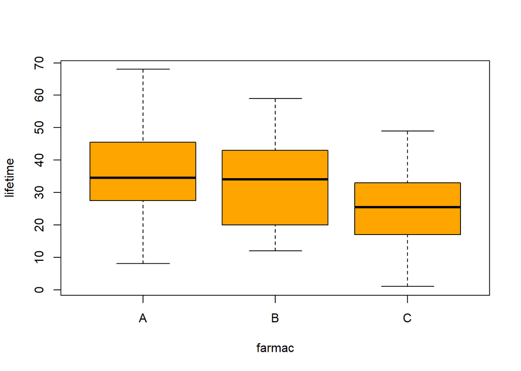

```r
boxplot(lifetime~farmac,cancer,col='orange')
```

Podem observar unes lleugeres diferències. Prou importants com per resultar estadísticament significatives?

## 1.3 Confirmació amb un ANOVA

```r
cancer.aov<-aov(lifetime~farmac,cancer)
anova(cancer.aov)
```

|  | Df | Sum Sq | Mean Sq | F value | Pr(>F) |
| --- | --- | --- | --- | --- | --- |
| farmac | 2 | 1041.60 | 520.8000 | 2.57213 | 0.0852127 |
| Residuals | 57 | 11541.25 | 202.4781 | NA | NA |

```r
model.tables(cancer.aov,type='mean')
```

```
## Tables of means
## Grand mean
##
## 30.95
##
##  farmac
## farmac
##     A     B     C
## 34.75 32.95 25.15
```

No tenim prou evidència estadística per rebutjar la hipòtesi nul·la d’igualtat dels tres tractaments?

**RECONSIDEREM LA DECISIÓ!!!!**

Pot haver alguna variable que ens amagui l’efecte dels tractaments. És el mateix que hem vist al parlar dels blocs en models ANOVA.

## 1.4 ANCOVA

- Un **ANCOVA** és un ANOVA amb covariables (variables continues que poden tenir influència a la variabale resposta).
- Bàsicament és una combinació del ANOVA i de la regressió.
- Les covariables també són anomenades *variables concomitants*.
- Afegir la covariable, tot i que no sigui d’interés primordial, pot reduir la variabilitat residual i permetre explicar millor la variable resposta.

## 1.5 Determinació de la covariable i verificació de la significació

En el nostre exemple creiem que el temps que ha passat des del diagnòstic (**Durada**) pot ser important. Si ha passat poc temps és probable que en promig la durada de la vida sigui més gran.

Primer verifiquem que realment el temps des del diagnòstic està relacionat amb el temps de vida.

```r
cancer.lm<-lm(lifetime~Durada,cancer)
summary(cancer.lm)
```

```
##
## Call:
## lm(formula = lifetime ~ Durada, data = cancer)
##
## Residuals:
##    Min     1Q Median     3Q    Max
## -8.223 -6.667  1.110  5.369  6.987
##
## Coefficients:
##             Estimate Std. Error t value Pr(>|t|)
## (Intercept) 77.38260    2.49751   30.98   <2e-16 ***
## Durada      -0.77195    0.03988  -19.36   <2e-16 ***
## ---
## Signif. codes:  0 '***' 0.001 '**' 0.01 '*' 0.05 '.' 0.1 ' ' 1
##
## Residual standard error: 5.392 on 58 degrees of freedom
## Multiple R-squared:  0.866,  Adjusted R-squared:  0.8637
## F-statistic: 374.8 on 1 and 58 DF,  p-value: < 2.2e-16
```

Podem visualitzar com han anat les coses.

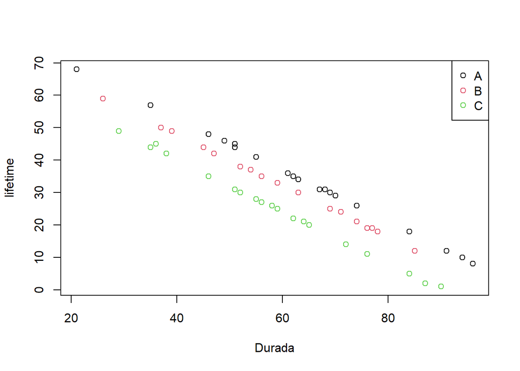

## 1.6 Resolem el model ANCOVA

Ull! Sempre la variable cuantitativa primer en la fòrmula!

```r
cancer.ancova<-lm(lifetime~Durada+farmac,cancer)
# Resultat equivalent per l'ANOVA fent servir la instrucció cancer.ancova.2<-aov(lifetime~Durada+farmac,cancer)
anova(cancer.ancova)
```

|  | Df | Sum Sq | Mean Sq | F value | Pr(>F) |
| --- | --- | --- | --- | --- | --- |
| Durada | 1 | 10896.454422 | 1.089645e+04 | 65147.831 | 0 |
| farmac | 2 | 1677.029166 | 8.385146e+02 | 5013.319 | 0 |
| Residuals | 56 | 9.366412 | 1.672574e-01 | NA | NA |

**ARA SI!!!**

## 1.7 Model lineal del ANCOVA

Hi han un parell de parametritzacions alternatives per representar un ANCOVA

### 1.7.1 Primera versió:

$$y_{ij} = \mu + \alpha_i + \beta X_{ij}
+ \epsilon_{ij}$$

És important notar que en aquest model $\mu$ **no** representa el promig global sobre la població sino que és el valor del punt de tall (Intercept) quan X=0.

### 1.7.2 Segona versió

Una parametrització alternativa s’aconsegueix si centrem els valors de $X$ restant el seu promig.

$$y_{ij} = \mu + \alpha_i + \beta
(X_{ij}-\bar{X}) + \epsilon_{ij}$$

on ara $\mu$ sí que representa el valor mitjà global de la variable resposta.

## 1.8 Estimació de paràmetres i model de regressió

Per obtenir els paràmetres estimats si hem fet servir la funció **lm** per la construcció

```r
summary(cancer.ancova)
```

```
##
## Call:
## lm(formula = lifetime ~ Durada + farmac, data = cancer)
##
## Residuals:
##      Min       1Q   Median       3Q      Max
## -0.59025 -0.29585  0.03199  0.18690  1.71804
##
## Coefficients:
##               Estimate Std. Error t value Pr(>|t|)
## (Intercept)  84.912414   0.211798  400.91   <2e-16 ***
## Durada       -0.798765   0.003042 -262.58   <2e-16 ***
## farmacB      -4.875244   0.129857  -37.54   <2e-16 ***
## farmacC     -12.874935   0.129928  -99.09   <2e-16 ***
## ---
## Signif. codes:  0 '***' 0.001 '**' 0.01 '*' 0.05 '.' 0.1 ' ' 1
##
## Residual standard error: 0.409 on 56 degrees of freedom
## Multiple R-squared:  0.9993, Adjusted R-squared:  0.9992
## F-statistic: 2.506e+04 on 3 and 56 DF,  p-value: < 2.2e-16
```

Si hem fet servir la funció **aov**

```r
cancer.ancova.2<-aov(lifetime~Durada+farmac,cancer)
coefficients(cancer.ancova.2)
```

```
## (Intercept)      Durada     farmacB     farmacC
##  84.9124136  -0.7987645  -4.8752435 -12.8749346
```

### 1.8.1 Model estimat

Finalment el model de regressió obtingut és:

lifetime = 84.9124136 + -0.7987645 · Durada + -4.8752435 · (Farmac = 2 (0=no,1=si)) + -12.8749346 · (Farmac = 3 (0=no,1=si))

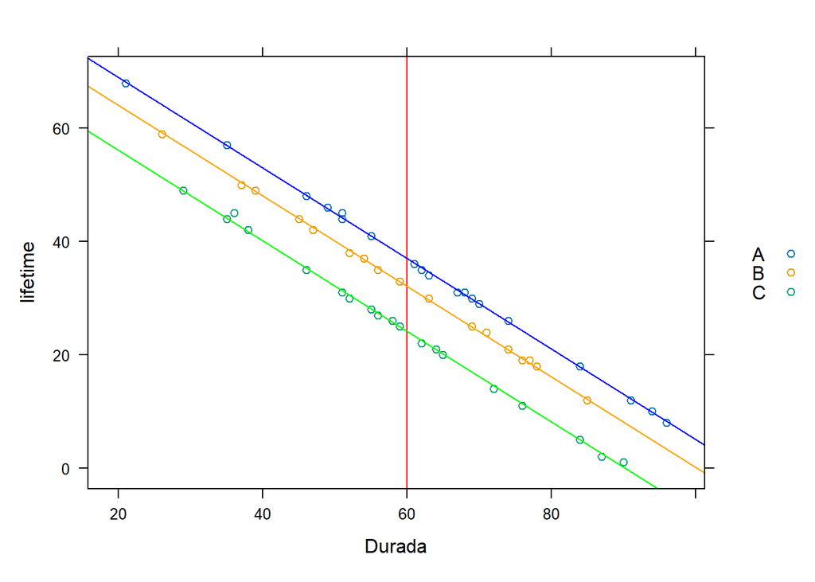

## 1.9 Comparacions múltiples

Cas de que la variable categòrica tingui més de dos factors podem fer les comparacions múltiples amb Tukey. Però hem de tenir en compte que no totes les funcions que fan un Tukey adequat a un ANOVA balancejat són adequades quan tenim covariables en el model.

Per exemple, si fem servir la funció **HSD.test** d’**agricolae**

```r
library(agricolae)
HSD.test(cancer.ancova,'farmac',console=T)
```

```
##
## Study: cancer.ancova ~ "farmac"
##
## HSD Test for lifetime
##
## Mean Square Error:  0.1672574
##
## farmac,  means
##
##   lifetime      std  r         se Min Max   Q25  Q50   Q75
## A    34.75 15.47111 20 0.09144872   8  68 28.25 34.5 45.25
## B    32.95 13.22070 20 0.09144872  12  59 20.50 34.0 42.50
## C    25.15 13.90295 20 0.09144872   1  49 18.50 25.5 32.00
##
## Alpha: 0.05 ; DF Error: 56
## Critical Value of Studentized Range: 3.404809
##
## Minimun Significant Difference: 0.3113654
##
## Treatments with the same letter are not significantly different.
##
##   lifetime groups
## A    34.75      a
## B    32.95      b
## C    25.15      c
```

Veiem que el package **agricolae** funciona amb les mitjanes senzilles entre els grups sense ajustar per la covariable.

```r
aggregate(cancer$lifetime,list(cancer$farmac),mean)
```

| Group.1 | x |
| --- | --- |
| A | 34.75 |
| B | 32.95 |
| C | 25.15 |

Si fem els càlculs amb el package **emmeans** s’utilitzen mitjanes marginals estimades (emmeans) que ajusten per covariables o factors addicionals. Emmeans funciona calculant mitjanes ajustades del model estadístic, com si preguntessis “quin seria el valor mitjà d’un grup si els altres factors o covariables estiguessin en el seu valor mitjà observat?

```r
library(emmeans)
emm<-emmeans(cancer.ancova,~farmac)
emm
```

```
##  farmac emmean     SE df lower.CL upper.CL
##  A       36.87 0.0918 56    36.68    37.05
##  B       31.99 0.0915 56    31.81    32.17
##  C       23.99 0.0916 56    23.81    24.18
##
## Confidence level used: 0.95
```

Veiem que la primera mitjana ajustada s’obté de

```r
(md<-mean(cancer$Durada))
```

```
## [1] 60.15
```

```r
84.912414-0.798765*60.15
```

```
## [1] 36.8667
```

i així succesivament

Finalment les comparacions múltiples són

```r
pairs(emm,adjust='Tukey')
```

```
##  contrast estimate    SE df t.ratio p.value
##  A - B        4.88 0.130 56  37.543 <0.0001
##  A - C       12.87 0.130 56  99.093 <0.0001
##  B - C        8.00 0.129 56  61.855 <0.0001
##
## P value adjustment: tukey method for comparing a family of 3 estimates
```

## 1.10 Premisses

- Els residus han de verificar les premisses habituals dels ANOVA

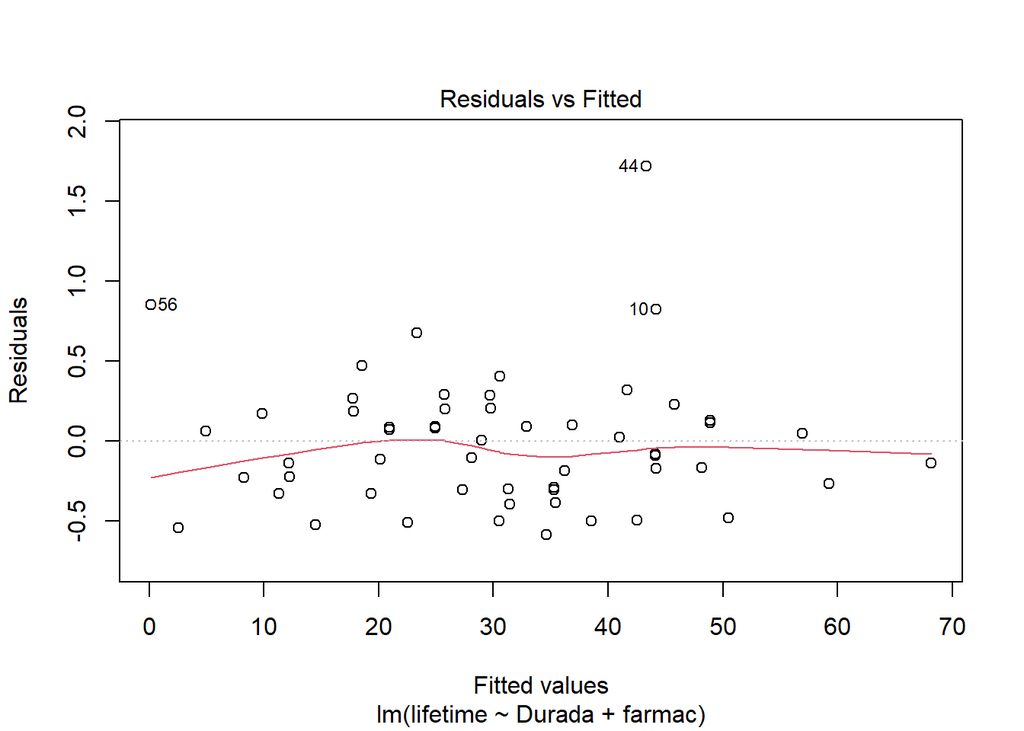

```r
plot(cancer.ancova,which=1)
```

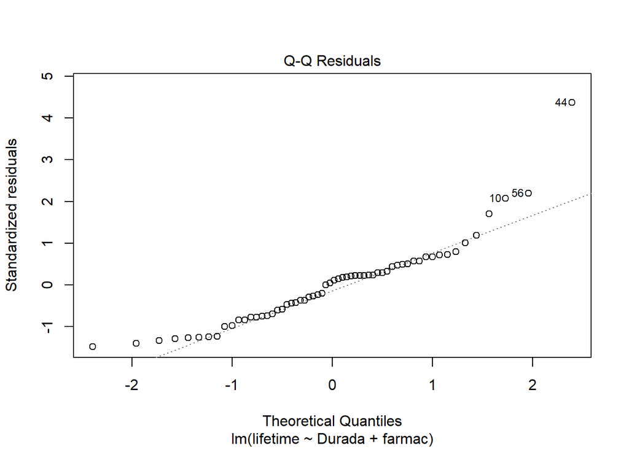

```r
plot(cancer.ancova,which=2)
```

- La covariable no s’ha de veure afectada pels factors experimentals. El valor esperat de la covariable ha de ser el mateix per a tots els individus. Es pot comprovar amb un ANOVA

```r
anova(aov(Durada~farmac,cancer))
```

|  | Df | Sum Sq | Mean Sq | F value | Pr(>F) |
| --- | --- | --- | --- | --- | --- |
| farmac | 2 | 211.30 | 105.6500 | 0.3331821 | 0.7180259 |
| Residuals | 57 | 18074.35 | 317.0939 | NA | NA |

- La covariable ha d’estar relacionada linealment amb la variable resposta i el coeficient de regressió (pendent) ha de ser el mateix per tots els nivells del factor. Aquesta premissa por ser visualitzada

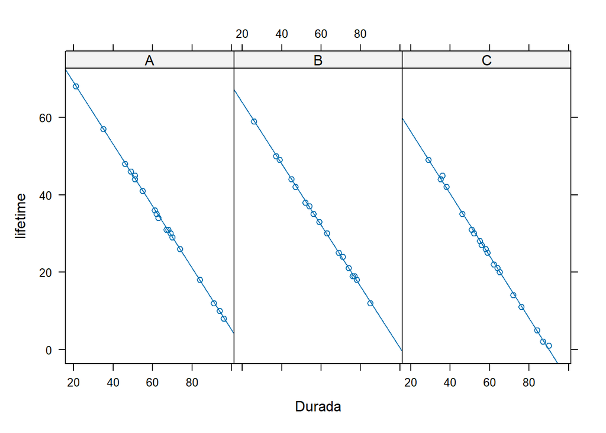

```r
library(lattice)
xyplot(lifetime~Durada|farmac, data=cancer, type=c("p", "r"))
```

i es pot verificar amb un contrast sobre la interacció de la covariable amb el factor

### 1.10.1 Model complet amb interacció

```r
cancer.ancova.full<-lm(lifetime~Durada*farmac,cancer)
anova(cancer.ancova.full)
```

|  | Df | Sum Sq | Mean Sq | F value | Pr(>F) |
| --- | --- | --- | --- | --- | --- |
| Durada | 1 | 1.089645e+04 | 1.089645e+04 | 67676.541998 | 0.0000000 |
| farmac | 2 | 1.677029e+03 | 8.385146e+02 | 5207.911232 | 0.0000000 |
| Durada:farmac | 2 | 6.719885e-01 | 3.359943e-01 | 2.086819 | 0.1339749 |
| Residuals | 54 | 8.694424e+00 | 1.610078e-01 | NA | NA |

Si la interacció fos significativa hauriem de construir models de regressió lineal diferents per cada nivell del factor **farmac**.

## 1.11 Exemple addicional amb pendents diferents: Relació entre fumar i FEV

El **volum expiratori forçat (FEV)** és una mesura de capacitat respiratòria definida com el volum que pot exhalar-en el primer segon durant una espiració forçada.

La FEV es mesura en % de la capacitat respiratòria total i s’ha observat que moltes malalties obstructives van acompanyades d’un descens en el FEV.

El fitxer **fev.csv** conté diverses variables mesurades sobre un conjunt de 654 individus joves entre 3 i 19 anys.

- Age: edat en anys.
- FEV: Volum màxim espirat forçadament en un segon
- Ht: Alçada en polzades.
- Gender: 0 = Home ; 1 = Dona
- Smoke: 1 = Fumador ; 0 = No fumador

La variable FEV ha estat transformada logarítmicament per millorar la normalitat i homocedasticitat del model.

```r
fev<-read.table('../dades/fev.csv',header=T,sep=';',dec=',',stringsAsFactors = T)
fev$FEV<-log(fev$FEV)
tail(fev)
```

|  | Age | FEV | Ht | Gender | Smoke |
| --- | --- | --- | --- | --- | --- |
| 649 | 16 | 1.583505 | 72.0 | Male | Yes |
| 650 | 16 | 1.451614 | 67.0 | Male | Yes |
| 651 | 15 | 1.315604 | 68.0 | Male | Yes |
| 652 | 18 | 1.048371 | 60.0 | Female | No |
| 653 | 16 | 1.027832 | 63.0 | Female | Yes |
| 654 | 15 | 1.166582 | 66.5 | Female | No |

### 1.11.1 Anàlisi descriptiu de les dades

```r
summary(fev)
```

```
##       Age              FEV                Ht           Gender    Smoke
##  Min.   : 3.000   Min.   :-0.2345   Min.   :46.00   Female:318   No :589
##  1st Qu.: 8.000   1st Qu.: 0.6836   1st Qu.:57.00   Male  :336   Yes: 65
##  Median :10.000   Median : 0.9351   Median :61.50
##  Mean   : 9.931   Mean   : 0.9154   Mean   :61.14
##  3rd Qu.:12.000   3rd Qu.: 1.1374   3rd Qu.:65.50
##  Max.   :19.000   Max.   : 1.7567   Max.   :74.00
```

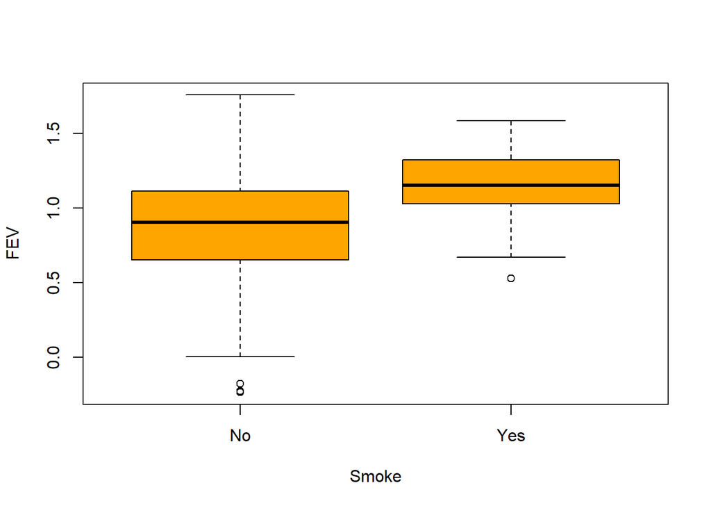

```r
boxplot(FEV~Smoke,fev,col='orange')
```

**Comencem a veure resultats anòmals?**

### 1.11.2 Confirmació amb un ANOVA

```r
fev.anova.smoke<-aov(FEV~Smoke,fev)
anova(fev.anova.smoke)
```

|  | Df | Sum Sq | Mean Sq | F value | Pr(>F) |
| --- | --- | --- | --- | --- | --- |
| Smoke | 1 | 4.333575 | 4.3335747 | 41.43414 | 0 |
| Residuals | 652 | 68.192340 | 0.1045895 | NA | NA |

Existeix una relació significativa entre fumar i el FEV però sembla que el valor de FEV és superior en aquells individus que fumen !!!

**Suposem que pot haver una influència de l’edat**

### 1.11.3 Verifiquem que la covariable és significativa

```r
fev.smoke.lm<-lm(FEV~Age,fev)
summary(fev.smoke.lm)
```

```
##
## Call:
## lm(formula = FEV ~ Age, data = fev)
##
## Residuals:
##      Min       1Q   Median       3Q      Max
## -0.72047 -0.13752  0.00302  0.14681  0.60267
##
## Coefficients:
##             Estimate Std. Error t value Pr(>|t|)
## (Intercept) 0.050596   0.029104   1.738   0.0826 .
## Age         0.087083   0.002809  31.000   <2e-16 ***
## ---
## Signif. codes:  0 '***' 0.001 '**' 0.01 '*' 0.05 '.' 0.1 ' ' 1
##
## Residual standard error: 0.212 on 652 degrees of freedom
## Multiple R-squared:  0.5958, Adjusted R-squared:  0.5952
## F-statistic:   961 on 1 and 652 DF,  p-value: < 2.2e-16
```

### 1.11.4 Verifiquem si és raonable assumir pendents iguals

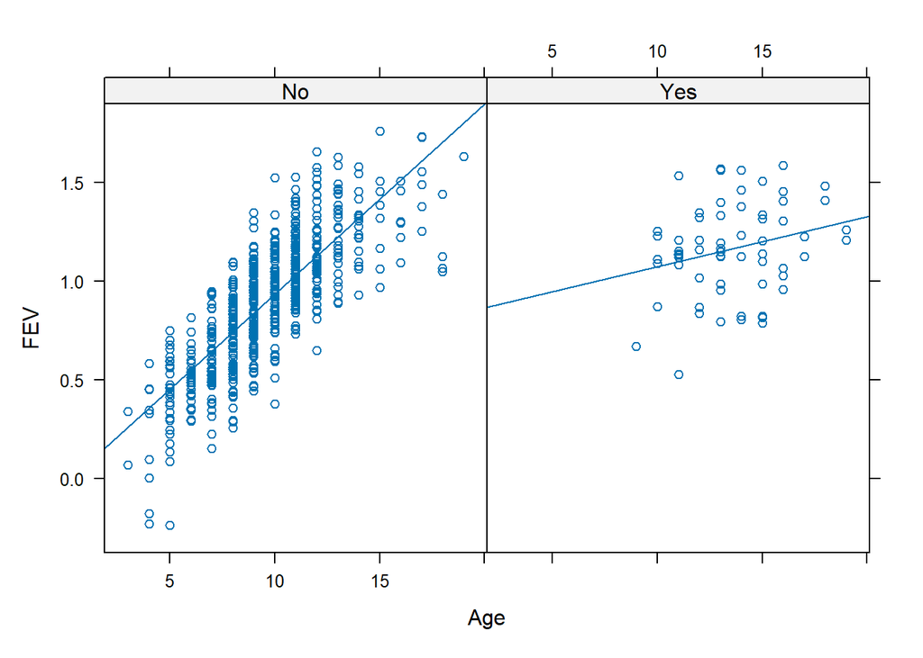

```r
library(lattice)
xyplot(FEV~Age|Smoke, data=fev, type=c("p", "r"))
```

### 1.11.5 Model complet amb interacció

```r
fev.ancova.full<-lm(FEV~Age*Smoke,fev)
anova(fev.ancova.full)
```

|  | Df | Sum Sq | Mean Sq | F value | Pr(>F) |
| --- | --- | --- | --- | --- | --- |
| Age | 1 | 43.2100549 | 43.2100549 | 1028.900300 | 0.0000000 |
| Smoke | 1 | 0.3960405 | 0.3960405 | 9.430355 | 0.0022233 |
| Age:Smoke | 1 | 1.6221934 | 1.6221934 | 38.627012 | 0.0000000 |
| Residuals | 650 | 27.2976261 | 0.0419963 | NA | NA |

```r
summary(fev.ancova.full)
```

```
##
## Call:
## lm(formula = FEV ~ Age * Smoke, data = fev)
##
## Residuals:
##      Min       1Q   Median       3Q      Max
## -0.68768 -0.12406  0.00093  0.13690  0.59106
##
## Coefficients:
##               Estimate Std. Error t value Pr(>|t|)
## (Intercept)  -0.026592   0.030590  -0.869    0.385
## Age           0.095963   0.003084  31.120  < 2e-16 ***
## SmokeYes      0.845513   0.153334   5.514 5.06e-08 ***
## Age:SmokeYes -0.070706   0.011376  -6.215 9.17e-10 ***
## ---
## Signif. codes:  0 '***' 0.001 '**' 0.01 '*' 0.05 '.' 0.1 ' ' 1
##
## Residual standard error: 0.2049 on 650 degrees of freedom
## Multiple R-squared:  0.6236, Adjusted R-squared:  0.6219
## F-statistic:   359 on 3 and 650 DF,  p-value: < 2.2e-16
```

La interacció significativa confirma que els pendents són diferents.

Això ens permet construir rectes diferents per cada nivell de Smoke

### 1.11.6 Rectes per a cada nivell de *Smoke*

- Per als **no fumadors**

– FEV = -0.0265917 + 0.0959628 · Age

- Per als **fumadors**

– FEV = 0.8189209 + 0.0252572 · Age

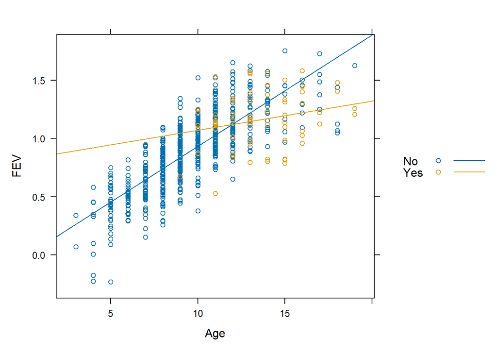

I ara podem obtenir prediccions de forma independent per cada nivell de Smoke

```
##        1        2
## 1.273551 1.700740
```

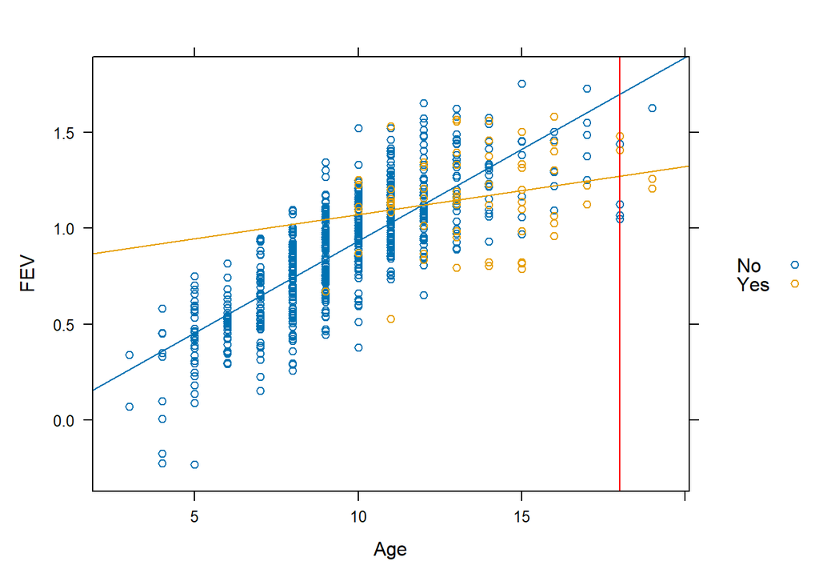

### 1.11.7 Càlcul de les rectes de forma independent

El resultat que hem obtingut amb l’ANCOVA és equivalent al càlcul de les rectes per cada nivell de Smoke per separat

```r
lm.smoke.no<-lm(FEV~Age,data=fev[fev$Smoke=='No',])
summary(lm.smoke.no)
```

```
##
## Call:
## lm(formula = FEV ~ Age, data = fev[fev$Smoke == "No", ])
##
## Residuals:
##      Min       1Q   Median       3Q      Max
## -0.68768 -0.12389 -0.00067  0.13634  0.59106
##
## Coefficients:
##              Estimate Std. Error t value Pr(>|t|)
## (Intercept) -0.026592   0.030190  -0.881    0.379
## Age          0.095963   0.003043  31.533   <2e-16 ***
## ---
## Signif. codes:  0 '***' 0.001 '**' 0.01 '*' 0.05 '.' 0.1 ' ' 1
##
## Residual standard error: 0.2022 on 587 degrees of freedom
## Multiple R-squared:  0.6288, Adjusted R-squared:  0.6282
## F-statistic: 994.3 on 1 and 587 DF,  p-value: < 2.2e-16
```

```r
lm.smoke.yes<-lm(FEV~Age,data=fev[fev$Smoke=='Yes',])
summary(lm.smoke.yes)
```

```
##
## Call:
## lm(formula = FEV ~ Age, data = fev[fev$Smoke == "Yes", ])
##
## Residuals:
##     Min      1Q  Median      3Q     Max
## -0.5697 -0.1573  0.0246  0.1561  0.4373
##
## Coefficients:
##             Estimate Std. Error t value Pr(>|t|)
## (Intercept)  0.81892    0.16748   4.890  7.3e-06 ***
## Age          0.02526    0.01221   2.069   0.0426 *
## ---
## Signif. codes:  0 '***' 0.001 '**' 0.01 '*' 0.05 '.' 0.1 ' ' 1
##
## Residual standard error: 0.2284 on 63 degrees of freedom
## Multiple R-squared:  0.06364,    Adjusted R-squared:  0.04878
## F-statistic: 4.282 on 1 and 63 DF,  p-value: 0.04263
```

## 1.12 Comentaris i exemple addicional

- El model ANCOVA clàssic inclou un factor i una o més covariables en un model additiu
- Poden construir-se models ANCOVA més generals combinant diversos factors amb diverses variables concomitants i també les seves interaccions

## 1.13 Exemple amb dues covariables: Resposta a l’estrès hídric

Com a exemple d’ANCOVA, agafarem un subconjunt de variables d’un estudi experimental dels efectes dels contaminants atmosfèrics de baix nivell i la sequera sobre els rendiments agrícoles. L’objectiu de l’experiment és veure com els rendiments de dues varietats de soja, anomenades Forrest i William, es veuen afectats per dos contaminants (ozó de baix nivell, $O_3$, i diòxid de sofre, $SO_2$) i com aquests contaminants interaccionen amb l’estrès hídric. Aquí només mirarem la varietat William, ja que mostra respostes més complexes. El dataframe, anomenat case1402, es troba al paquet R **Sleuth3**.

```r
library(Sleuth3)
head(case1402)
```

| Stress | SO2 | O3 | Forrest | William |
| --- | --- | --- | --- | --- |
| Well-watered | 0.00 | 0.02 | 4376 | 5561 |
| Well-watered | 0.00 | 0.05 | 4544 | 5947 |
| Well-watered | 0.00 | 0.07 | 2806 | 4273 |
| Well-watered | 0.00 | 0.08 | 3339 | 3470 |
| Well-watered | 0.00 | 0.10 | 3320 | 3080 |
| Well-watered | 0.02 | 0.02 | 3747 | 5092 |

```r
summary(case1402)
```

```
##           Stress        SO2                O3           Forrest
##  Stressed    :15   Min.   :0.00000   Min.   :0.020   Min.   :2158
##  Well-watered:15   1st Qu.:0.00000   1st Qu.:0.050   1st Qu.:3245
##                    Median :0.02000   Median :0.070   Median :3478
##                    Mean   :0.02667   Mean   :0.064   Mean   :3699
##                    3rd Qu.:0.06000   3rd Qu.:0.080   3rd Qu.:4327
##                    Max.   :0.06000   Max.   :0.100   Max.   :5573
##     William
##  Min.   :2101
##  1st Qu.:2889
##  Median :3428
##  Mean   :3635
##  3rd Qu.:4263
##  Max.   :5947
```

Primer mirarem si hi han diferències entre el rendiment de les plantes de la varietat William sotmeses a diferent nivell hídric. Ho farem amb un anova amb el logaritme de la variable resposta

```r
w0<-lm(log(William)~Stress,case1402)
anova(w0)
```

|  | Df | Sum Sq | Mean Sq | F value | Pr(>F) |
| --- | --- | --- | --- | --- | --- |
| Stress | 1 | 0.2376424 | 0.2376424 | 3.872874 | 0.0590476 |
| Residuals | 28 | 1.7181003 | 0.0613607 | NA | NA |

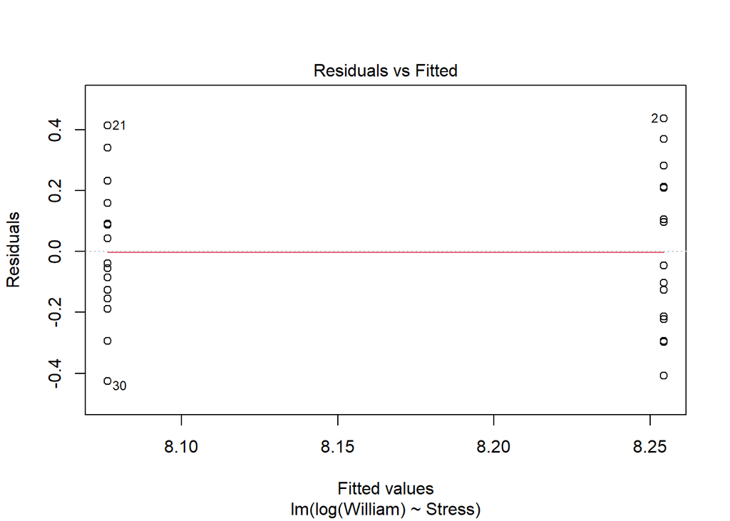

```r
plot(w0,which=1)
```

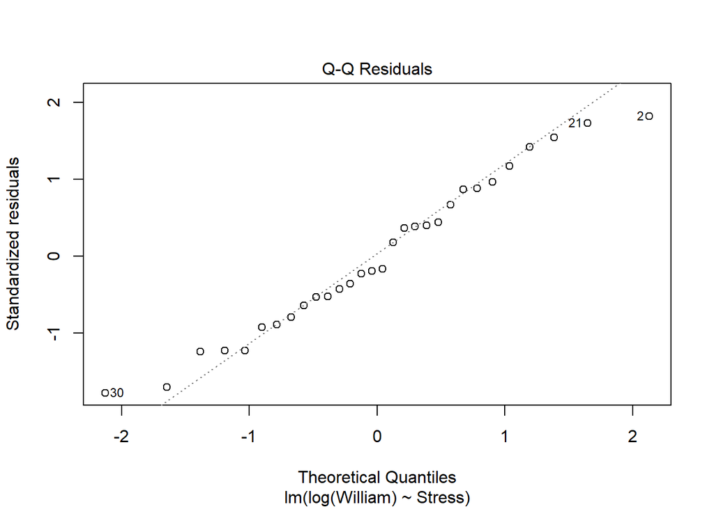

```r
plot(w0,which=2)
```

Ajustem ara un model amb els contaminants atmosfèrics com a covariables

```r
w1 <- lm(log(William) ~ O3 * SO2 *Stress, data = case1402)
anova(w1)
```

|  | Df | Sum Sq | Mean Sq | F value | Pr(>F) |
| --- | --- | --- | --- | --- | --- |
| O3 | 1 | 1.1381194 | 1.1381194 | 85.7564312 | 0.0000000 |
| SO2 | 1 | 0.2655814 | 0.2655814 | 20.0113588 | 0.0001898 |
| Stress | 1 | 0.2376424 | 0.2376424 | 17.9061705 | 0.0003427 |
| O3:SO2 | 1 | 0.0028089 | 0.0028089 | 0.2116475 | 0.6499936 |
| O3:Stress | 1 | 0.0101286 | 0.0101286 | 0.7631857 | 0.3917698 |
| SO2:Stress | 1 | 0.0023750 | 0.0023750 | 0.1789546 | 0.6763797 |
| O3:SO2:Stress | 1 | 0.0071132 | 0.0071132 | 0.5359731 | 0.4718342 |
| Residuals | 22 | 0.2919738 | 0.0132715 | NA | NA |

No sembla haver evidència d’interaccions, ho verifiquem

```r
w2<-lm(log(William) ~ O3 + SO2 +Stress, data = case1402)
anova(w1,w2)
```

| Res.Df | RSS | Df | Sum of Sq | F | Pr(>F) |
| --- | --- | --- | --- | --- | --- |
| 22 | 0.2919738 | NA | NA | NA | NA |
| 26 | 0.3143995 | -4 | -0.0224257 | 0.4224402 | 0.7907276 |

Finalment ens quedem amb el model

```r
anova(w2)
```

|  | Df | Sum Sq | Mean Sq | F value | Pr(>F) |
| --- | --- | --- | --- | --- | --- |
| O3 | 1 | 1.1381194 | 1.1381194 | 94.11945 | 0.0000000 |
| SO2 | 1 | 0.2655814 | 0.2655814 | 21.96288 | 0.0000769 |
| Stress | 1 | 0.2376424 | 0.2376424 | 19.65239 | 0.0001501 |
| Residuals | 26 | 0.3143995 | 0.0120923 | NA | NA |

Per tant veiem un efectes significatiu de l’estrès hídric, un major estrès provoca un pitjor rendiment

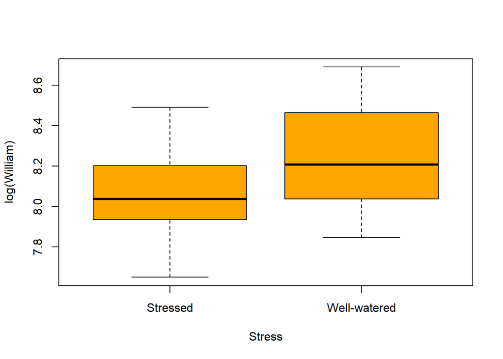

```r
boxplot(log(William)~Stress,case1402,col='orange')
```

i també un efecte negatiu de la presència de contaminants atmosfèrics

```r
summary(w2)
```

```
##
## Call:
## lm(formula = log(William) ~ O3 + SO2 + Stress, data = case1402)
##
## Residuals:
##       Min        1Q    Median        3Q       Max
## -0.254975 -0.058157 -0.000703  0.054103  0.235750
##
## Coefficients:
##                    Estimate Std. Error t value Pr(>|t|)
## (Intercept)         8.63393    0.05904 146.235  < 2e-16 ***
## O3                 -7.14080    0.73605  -9.702 3.97e-10 ***
## SO2                -3.77195    0.80486  -4.686 7.69e-05 ***
## StressWell-watered  0.17800    0.04015   4.433  0.00015 ***
## ---
## Signif. codes:  0 '***' 0.001 '**' 0.01 '*' 0.05 '.' 0.1 ' ' 1
##
## Residual standard error: 0.11 on 26 degrees of freedom
## Multiple R-squared:  0.8392, Adjusted R-squared:  0.8207
## F-statistic: 45.24 on 3 and 26 DF,  p-value: 1.848e-10
```